# Intervalo de Confiança para o Tempo de Execução

Rafael Tenfen

Data de entrega: 07/05/2021

# Descrição da atividade

O objetivo desta atividade é aplicar o conceito de intervalo de confiança à medição do tempo de execução de uma função.

Algumas recomendações:

- Se você não estiver habituado com R Markdown, acostume-se a processar com frequência o documento, usando o botão **Knit**. Isso permitirá que eventuais erros no documento ou no código R sejam identificados rapidamente, pouco depois de terem sido cometidos, o que facilitará sua correção. Na verdade, é uma boa ideia você fazer isso **agora**, para garantir que seu ambiente esteja configurado corretamente. Se você receber uma mensagem de erro do tipo *Error in library(foo)*, isso significa que o pacote `foo` não está instalado. Para instalar um pacote, execute o comando `install.packages("foo")` no Console, ou clique em *Tools* -> *Install Packages*.
- Após concluir a atividade, você deverá submeter no Moodle um arquivo ZIP contendo:
  - o arquivo fonte .Rmd;
  - a saída processada (PDF ou HTML) do arquivo .Rmd;
  - o(s) arquivo(s) de dados necessário(s) para o processamento do .Rmd, caso você opte por salvar os dados analisados separadamente.

# Configuração

Nesta atividade, a única configuração necessária consiste em carregar o arquivo `rand171.R`, que contém a função `rand171()`, cujo tempo de execução será medido.

```r
source("rand171.R")         # carrega arquivo que contem a funcao
```

# Salvando seus dados

Este é um experimento iterativo com dados que não se repetem: você irá realizar uma primeira rodada de execuções, analisar os dados dessa rodada para determinar quantas execuções adicionais serão necessárias, e analisar os dados da segunda rodada para saber se serão necessárias mais execuções. Nesse processo, você irá trabalhando com os dados à medida em que eles são obtidos. Ao final do processo, você precisa:

- salvar seus dados em um arquivo;
- escrever sua análise dos dados com base nos dados salvos.

O salvamento dos dados é importante porque eles estarão disponíveis no seu ambiente, mas não para quem receber o seu arquivo .Rmd. Assim, os dados precisam ser fornecidos de alguma forma para que seja possível reprocessar o arquivo .Rmd e reproduzir a análise usando os dados originais.

Você pode salvar seus dados de duas formas. A primeira é preservá-los no próprio arquivo .Rmd, e a segunda é usando um arquivo de dados auxiliar.

## Salvando os dados no próprio arquivo .Rmd

Supondo que seus tempos de execução estejam armazenados em um vetor `texec`, você pode usar a função `dput()` para mostrar o conteúdo do vetor de modo que possa ser atribuído a uma variável. O código abaixo demonstra isso com um vetor `x`:

```r
x <- 2^c(1:8)
dput(x)
```

```
## c(2, 4, 8, 16, 32, 64, 128, 256)
```

Veja que `dput()` enumera os elementos do vetor em um formato que permite a atribuição a uma variável: os valores de `x` poderiam ser preservados colocando `x <- c(2, 4, 8, 16, 32, 64, 128, 256)` em um bloco R no arquivo .Rmd. Você pode usar a mesma estratégia para preservar os valores de `texec`.

## Salvando os dados em um arquivo auxiliar

Supondo novamente que seus tempos de execução estejam armazenados em um vetor `texec`, o código abaixo mostra como salvá-los em um arquivo `texec-rand171.dat`.

```r
# texec contém os tempos de execução medidos no experimento
df <- data.frame(texec)
write.table(df, "texec-rand171.dat", row.names = FALSE, quote = FALSE)
```

O código abaixo pode ser usado para recuperar `texec` a partir do arquivo salvo pelo código anterior:

```r
texec <- read.table("texec-rand171.dat", header = TRUE)$texec
```

Caso você opte por salvar os dados em um arquivo separado, o comando que lê os dados do arquivo deve ser incluído no seu bloco R de análise.

# Definição do experimento

A função `rand171()` encontra `noc` ocorrências do número 171 em uma sequência de números aleatórios, e imprime e retorna o seu tempo de execução (em segundos).

```r
#qnorm()

#rand171(33)
#rand171(33)
#rand171(33)

rand171(5)
```

```
## tempo de execucao=0.502 s
```

```
## [1] 0.5022793
```

1. Determine o número $n$ de execuções necessárias para obter, com 95% de confiança, o tempo médio de execução com uma margem de erro de $\pm 6\%$. Considere uma amostra inicial de 5 execuções. Se necessário, ajuste o parâmetro `noc` para que o tempo de execução fique na ordem de 3 a 5 s (o valor *default* é 20, que deve ser adequado para o RStudio Cloud). Para obter $n$, use a equação 4.21 (pág. 53) do livro; adote $e=0.06$, e lembre-se que o coeficiente $z$ deve ser obtido da distribuição $t$ (pois a amostra inicial tem 5 elementos).
2. Realize o número de execuções determinadas no passo anterior, e calcule o intervalo de confiança de 95% para a média. Observe que você deve considerar as 5 execuções iniciais: por exemplo, se no passo 1 você descobriu que são necessárias 25 execuções, execute a função mais 20 vezes, e calcule o IC usando todas as 25 execuções.
3. O IC obtido no item anterior fica dentro da margem de erro desejada de $\pm 6\%$? Caso contrário, amplie a amostra até obter a margem pretendida, e informe o novo IC calculado e quantas execuções foram necessárias ao final. A margem de erro é dada por
   $$e = \frac{zs}{\bar{x}\sqrt{n}}$$
   onde o coeficiente $z$ deve ser obtido da distribuição $t$ (se $n < 30$) ou da distribuição normal (se $n \geq 30$). Para obter uma porcentagem, multiplique $e$ por 100.
4. Compare os histogramas dos tempos de execução obtidos nos passos 1, 2 e 3 (se houver).

# Respostas

Como explicado acima, você deve salvar os dados obtidos durante a realização do experimento e depois escrever sua análise com base nos dados salvos. *Trabalhe com os tempos já coletados, não é necessário realizar novas execuções de `rand171()`.*

A forma mais fácil de fazer isso é usando um bloco separado para cada uma das questões 1 a 4. Você pode adaptar a estrutura abaixo para isso.

```r
# código para recuperar os tempos de execução mensurados aqui

randData <- c()
noc3to5s <- 34
initialExec <- 5

# generate 5 initial executions
for (i in 1:initialExec) {
  randData <- c(randData, rand171(noc3to5s))
}
```

```
## tempo de execucao=3.697 s
## tempo de execucao=3.667 s
## tempo de execucao=4.819 s
## tempo de execucao=4.273 s
## tempo de execucao=4.689 s
```

```r
df5 <- data.frame(randData)
write.table(df5, "randData5-rand171.dat", row.names = FALSE, quote = FALSE)
dput(randData)
```

```
## c(3.6969633102417, 3.66661548614502, 4.8185510635376, 4.27341055870056,
## 4.68949174880981)
```

### Questão 1

```r
# código para analisar os dados da questão 1 aqui

xbar <- mean(randData)
s <- sd(randData)
e <- 0.06
ic <- 0.95
alfa <- 1 - ic
p <- 1 - alfa/2


z <- qnorm(p)
if (initialExec < 30) {
  z <- qt(p, initialExec - 1)
}

nest <- (z*s/(e*xbar))^2
nestCeil <- ceiling(nest)
nestCeil
```

```
## [1] 35
```

Resposta para a questão 1: São necessários 35 amostras

### Questão 2

```r
# código para analisar os dados da questão 2 aqui
randDataN <- randData

if (nestCeil < initialExec) { # to avoid negative numbers on for
  # enter here and it would be 1:0, generating + 1 to randDataN
  nestCeil <- initialExec
}

for (i in 1:(nestCeil - initialExec)) {
  randDataN <- c(randDataN, rand171(noc3to5s))
}
```

```
## tempo de execucao=4.808 s
## tempo de execucao=4.554 s
## tempo de execucao=4.306 s
## tempo de execucao=4.228 s
## tempo de execucao=2.929 s
## tempo de execucao=3.917 s
## tempo de execucao=2.861 s
## tempo de execucao=3.937 s
## tempo de execucao=4.095 s
## tempo de execucao=3.834 s
## tempo de execucao=3.540 s
## tempo de execucao=4.170 s
## tempo de execucao=4.397 s
## tempo de execucao=3.623 s
## tempo de execucao=2.663 s
## tempo de execucao=4.318 s
## tempo de execucao=3.023 s
## tempo de execucao=2.839 s
## tempo de execucao=4.009 s
## tempo de execucao=4.778 s
## tempo de execucao=3.783 s
## tempo de execucao=3.067 s
## tempo de execucao=3.453 s
## tempo de execucao=3.786 s
## tempo de execucao=4.141 s
## tempo de execucao=4.206 s
## tempo de execucao=3.160 s
## tempo de execucao=3.255 s
## tempo de execucao=3.424 s
## tempo de execucao=4.515 s
```

```r
dput(randDataN)
```

```
## c(3.6969633102417, 3.66661548614502, 4.8185510635376, 4.27341055870056,
## 4.68949174880981, 4.80771899223328, 4.55368733406067, 4.30567860603333,
## 4.22750020027161, 2.92869830131531, 3.91707992553711, 2.86071872711182,
## 3.9365062713623, 4.09508109092712, 3.83351421356201, 3.54035925865173,
## 4.16991353034973, 4.39667630195618, 3.62258338928223, 2.66321778297424,
## 4.31777882575989, 3.02285408973694, 2.83875250816345, 4.00912022590637,
## 4.77778935432434, 3.78257513046265, 3.06717324256897, 3.45305943489075,
## 3.78643989562988, 4.14124631881714, 4.20613098144531, 3.16048240661621,
## 3.25463533401489, 3.42360687255859, 4.51494956016541)
```

```r
dfN <- data.frame(randDataN)
write.table(dfN, "randDataN-rand171.dat", row.names = FALSE, quote = FALSE)
```

```r
randDataN.ic <- t.test(randDataN, conf.level=0.95)
#randDataN.ic

#str(randDataN.ic)
#randDataN.ic$conf.int
```

Resposta para a questão 2: IC 3.6399035, 4.0606999

```r
# código para analisar os dados da questão 3 aqui
randDataErrorMargin <- randDataN
xbar <- mean(randDataErrorMargin)
s <- sd(randDataErrorMargin)

ic <- 0.95
alfa <- 1 - ic
p <- 1 - alfa/2

z <- qnorm(p)
if (length(randDataErrorMargin) < 30) {
  z <- qt(p, length(randDataErrorMargin) - 1)
}

e = ((z * s) / (xbar * sqrt(length(randDataErrorMargin)))) * 100

e
```

```
## [1] 5.270106
```

```r
while (e > 6) {
  randDataErrorMargin <- c(randDataErrorMargin, rand171(noc3to5s))

  xbar <- mean(randDataErrorMargin)
  s <- sd(randDataErrorMargin)
  z <- qnorm(p)
  if (length(randDataErrorMargin) < 30) {
    z <- qt(p, length(randDataErrorMargin) - 1)
  }
  e = ((z * s) / (xbar * sqrt(length(randDataErrorMargin)))) * 100
  e
}

dput(randDataErrorMargin)
```

```
## c(3.6969633102417, 3.66661548614502, 4.8185510635376, 4.27341055870056,
## 4.68949174880981, 4.80771899223328, 4.55368733406067, 4.30567860603333,
## 4.22750020027161, 2.92869830131531, 3.91707992553711, 2.86071872711182,
## 3.9365062713623, 4.09508109092712, 3.83351421356201, 3.54035925865173,
## 4.16991353034973, 4.39667630195618, 3.62258338928223, 2.66321778297424,
## 4.31777882575989, 3.02285408973694, 2.83875250816345, 4.00912022590637,
## 4.77778935432434, 3.78257513046265, 3.06717324256897, 3.45305943489075,
## 3.78643989562988, 4.14124631881714, 4.20613098144531, 3.16048240661621,
## 3.25463533401489, 3.42360687255859, 4.51494956016541)
```

```r
dfN <- data.frame(randDataErrorMargin)
write.table(dfN, "randDataErrorMargin-rand171.dat", row.names = FALSE, quote = FALSE)
```

```r
randDataErrorMargin.ic <- t.test(randDataErrorMargin, conf.level=0.95)
randDataErrorMargin.ic
```

```
##
##  One Sample t-test
##
## data:  randDataErrorMargin
## t = 37.19, df = 34, p-value < 2.2e-16
## alternative hypothesis: true mean is not equal to 0
## 95 percent confidence interval:
##  3.639904 4.060700
## sample estimates:
## mean of x
##  3.850302
```

Resposta para a questão 3: Foram necessário 35 amostras para ficar dentro da margem de erro desejada de 6% e o novo IC é 3.6399035, 4.0606999

```r
# código para buscar os dados da questão 4 aqui

q1 <- read.table("randData5-rand171.dat", header = TRUE)$randData
q1
```

```
## [1] 3.696963 3.666615 4.818551 4.273411 4.689492
```

```r
q2 <- read.table("randDataN-rand171.dat", header = TRUE)$randDataN
q2
```

```
##  [1] 3.696963 3.666615 4.818551 4.273411 4.689492 4.807719 4.553687 4.305679
##  [9] 4.227500 2.928698 3.917080 2.860719 3.936506 4.095081 3.833514 3.540359
## [17] 4.169914 4.396676 3.622583 2.663218 4.317779 3.022854 2.838753 4.009120
## [25] 4.777789 3.782575 3.067173 3.453059 3.786440 4.141246 4.206131 3.160482
## [33] 3.254635 3.423607 4.514950
```

```r
q3 <- read.table("randDataErrorMargin-rand171.dat", header = TRUE)$randDataErrorMargin
q3
```

```
##  [1] 3.696963 3.666615 4.818551 4.273411 4.689492 4.807719 4.553687 4.305679
##  [9] 4.227500 2.928698 3.917080 2.860719 3.936506 4.095081 3.833514 3.540359
## [17] 4.169914 4.396676 3.622583 2.663218 4.317779 3.022854 2.838753 4.009120
## [25] 4.777789 3.782575 3.067173 3.453059 3.786440 4.141246 4.206131 3.160482
## [33] 3.254635 3.423607 4.514950
```

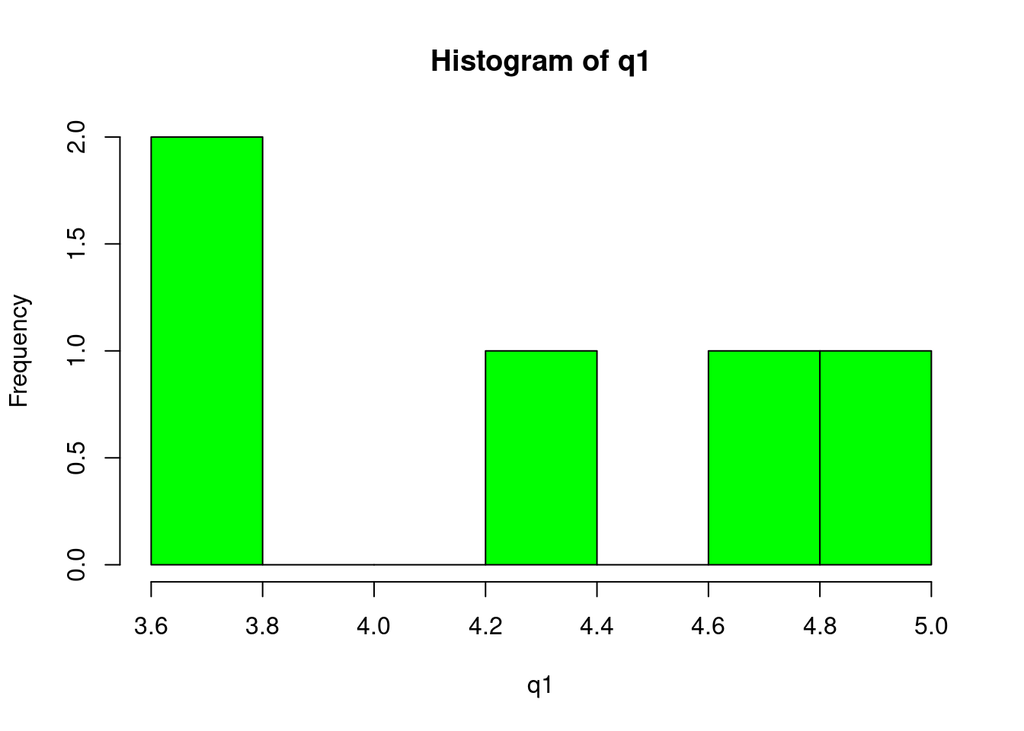

```r
hist(q1, col = "GREEN", breaks=5)
```

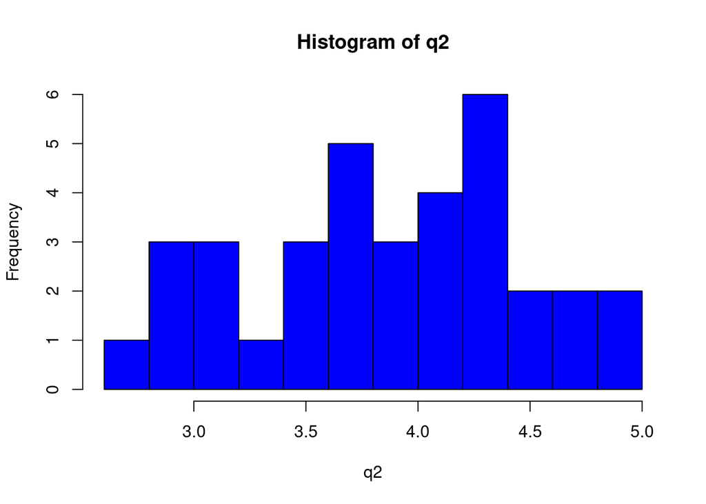

```r
hist(q2, col = "BLUE", breaks=15)
```

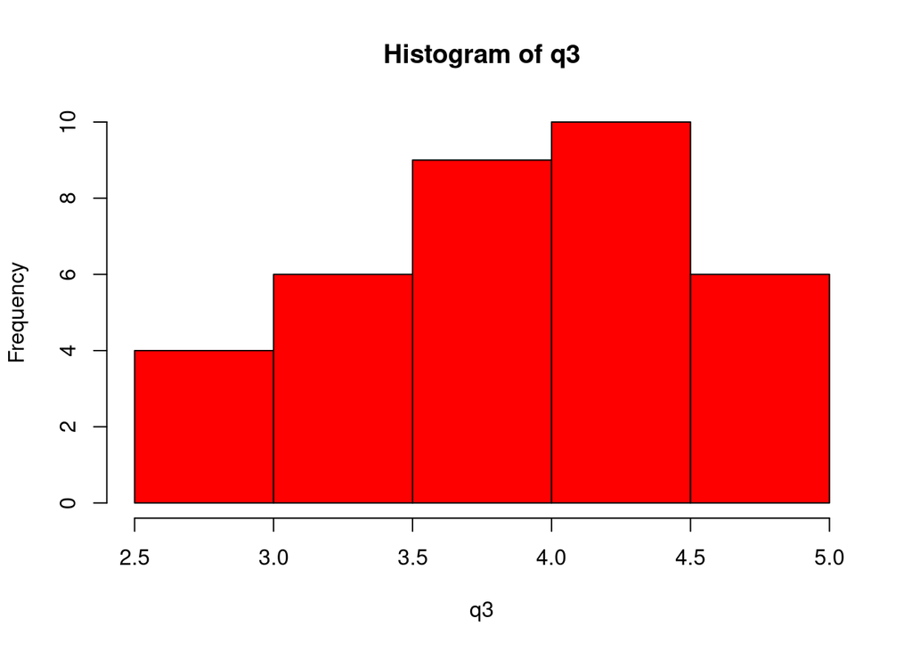

```r
hist(q3, col = "RED", breaks=5)
```

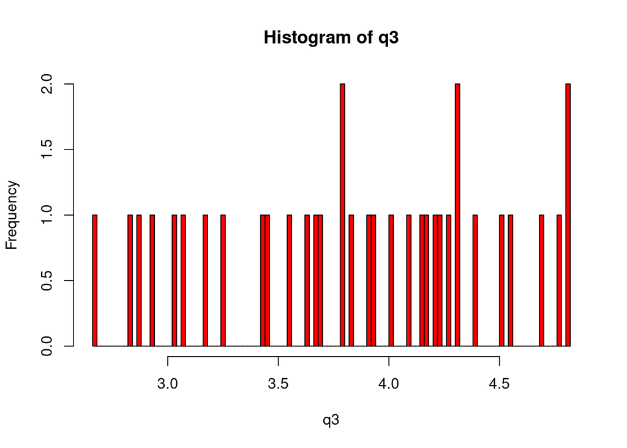

```r
hist(q3, col = "RED", breaks=80)
```

…